# Reading Data

Thomas W. Valente and George G. Vega Yon

# Diffusion Network Object (diffnet)

- **netdiffuseR** has its own class of objects: `diffnet`.
- Most of the package’s functions accept different types of graphs:
  - Static: `matrix`, `dgCMatrix` (from the **Matrix** pkg),
  - Dynamic: `list` + `dgCMatrix`, `array`, `diffnet`
- But `diffnet` is the class from which you get the most.
- From **netdiffuseR**’s perspective, network data comes in three classes:
  1. Raw R network data: Datasets with edgelist, attributes, survey data, etc.
  2. Already R data: already read into R using igraph, statnet, etc. (`igraph_to_diffnet`, `network_to_diffnet`, etc.)
  3. Graph files: DL, UCINET, pajek, etc. (`read_pajek`, `read_dl`, `read_ucinet`, etc.)
- In this presentation we will show focus on 1.

# What is a `diffnet` object

A diffusion network, a.k.a. `diffnet` object, is a `list` that holds the following objects:

- `graph`: A `list` with $t$ `dgCMatrix` matrices of size $n\times n$,
- `toa`: An integer vector of length $n$,
- `adopt`: A matrix of size $n\times t$,
- `cumadopt`: A matrix of size $n\times t$,
- `vertex.static.attrs`: A `data.frame` of size $n\times k$,
- `vertex.dyn.attrs`: A list with $t$ dataframes of size $n\times k$,
- `graph.attrs`: Currently ignored…, and
- `meta`: A list with metadata about the object.

These are created using `new_diffnet` (or its wrappers).

# Basic Diffusion Network

- To create `diffnet` objects we only need a network and times of adoption:

  ```r
  set.seed(9)

  # Network
  net <- rgraph_ws(500, 4, .2)

  # Times of adoption
  toa <- sample(c(NA, 2010:2014), 500, TRUE)

  diffnet_static <- as_diffnet(net, toa)
  ```

  ```
  # Warning in new_diffnet(graph, ...): -graph- is static and will be recycled
  # (see ?new_diffnet).
  ```

  ```r
  summary(diffnet_static)
  ```

  ```
  # Diffusion network summary statistics
  # Name     : Diffusion Network
  # Behavior : Unspecified
  # -----------------------------------------------------------------------------
  #  Period   Adopters   Cum Adopt. (%)   Hazard Rate   Density   Moran's I (sd)
  # -------- ---------- ---------------- ------------- --------- ----------------
  #     2010         90        90 (0.18)             -      0.01  0.00 (0.00)
  #     2011         72       162 (0.32)          0.18      0.01  0.00 (0.00) *
  #     2012         79       241 (0.48)          0.23      0.01 -0.00 (0.00)
  #     2013         83       324 (0.65)          0.32      0.01 -0.01 (0.00) **
  #     2014         93       417 (0.83)          0.53      0.01 -0.01 (0.00) *
  # -----------------------------------------------------------------------------
  #  Left censoring  : 0.18 (90)
  #  Right centoring : 0.17 (83)
  #  # of nodes      : 500
  #
  #  Moran's I was computed on contemporaneous autocorrelation using 1/geodesic
  #  values. Significane levels  *** <= .01, ** <= .05, * <= .1.
  ```

# Static survey

- netdiffuseR can also read survey (nomination) data:

  ```r
  data("fakesurvey")
  fakesurvey
  ```

  ```
  #   id toa group net1 net2 net3 age gender
  # 1  1   1     1   NA   NA   NA  30      M
  # 2  2   5     1    3    1   NA  35      F
  # 3  3   5     1   NA    2   NA  31      F
  # 4  4   3     1    6    5   NA  30      M
  # 5  5   2     1    4    4    3  40      F
  # 6  1   4     2    3    4    8  29      F
  # 7  2   3     2    3   NA   NA  35      M
  # 8  5   3     2   10    1   NA  50      M
  # 9 10  NA     2    5    1   NA  19      F
  #                                     note
  # 1                         No nominations
  # 2                          Nothing weird
  # 3                 Only nominates in net2
  # 4 Nominates someone who wasn't interview
  # 5                  Nominates 4 two times
  # 6               Only nominates outsiders
  # 7                               Isolated
  # 8                          Nothing weird
  # 9                            Non-adopter
  ```

- In group one 4 nominates id 6, who does not show in the data, and in group two 1 nominates 3, 4, and 8, also individuals who don’t show up in the survey.

  ```r
  d1 <- survey_to_diffnet(
    dat      = fakesurvey,                # Dataset
    idvar    = "id",                      # The name of the idvar
    netvars  = c("net1", "net2", "net3"), # Name of the nomination variables
    groupvar = "group",                   # Group variable (if any)
    toavar   = "toa"                      # Name of the time of adoption variable
    ); d1
  ```

  ```
  # Dynamic network of class -diffnet-
  #  Name               : Diffusion Network
  #  Behavior           : Unspecified
  #  # of nodes         : 9 (101, 102, 103, 104, 105, 201, 202, 205, ...)
  #  # of time periods  : 5 (1 - 5)
  #  Type               : directed
  #  Final prevalence   : 0.89
  #  Static attributes  : group, net1, net2, net3, age, gender, note (7)
  #  Dynamic attributes : -
  ```

- If you want to include those, you can use the option `no.unsurveyed`

  ```r
  d2 <- survey_to_diffnet(
    dat      = fakesurvey,
    idvar    = "id",
    netvars  = c("net1", "net2", "net3"),
    groupvar = "group",
    toavar   = "toa",
    no.unsurveyed = FALSE
    ); d2
  ```

  ```
  # Dynamic network of class -diffnet-
  #  Name               : Diffusion Network
  #  Behavior           : Unspecified
  #  # of nodes         : 13 (101, 102, 103, 104, 105, 106, 201, 202, ...)
  #  # of time periods  : 5 (1 - 5)
  #  Type               : directed
  #  Final prevalence   : 0.62
  #  Static attributes  : group, net1, net2, net3, age, gender, note (7)
  #  Dynamic attributes : -
  ```

- We can also check the difference

  ```r
  d2 - d1
  ```

  ```
  # Dynamic network of class -diffnet-
  #  Name               : Diffusion Network
  #  Behavior           : Unspecified
  #  # of nodes         : 4 (106, 203, 204, 208)
  #  # of time periods  : 5 (1 - 5)
  #  Type               : directed
  #  Final prevalence   : 0.00
  #  Static attributes  : group, net1, net2, net3, age, gender, note (7)
  #  Dynamic attributes : -
  ```

  ```r
  rownames(d2 - d1)
  ```

  ```
  # [1] "106" "203" "204" "208"
  ```

# Dynamic survey

```r
data("fakesurveyDyn")
fakesurveyDyn
```

```
#    id  toa group net1 net2 net3 age gender
# 1   1 1991     1   NA   NA   NA  30      M
# 2   2 1990     1    3    1   NA  35      F
# 3   3 1991     1   NA    2   NA  31      F
# 4   4 1990     1    6    5   NA  30      M
# 5   5 1991     1    4    4    3  40      F
# 6   1 1991     2    3    4    8  29      F
# 7   2 1990     2    3   NA   NA  35      M
# 8   5 1990     2   10    1   NA  50      M
# 9  10 1990     2    5    1   NA  19      F
# 10  1 1991     1   NA   NA   NA  31      M
# 11  2 1990     1    3    1   NA  36      F
# 12  3 1991     1   NA    2   NA  32      F
# 13  4 1990     1    6    5   NA  31      M
# 14  5 1991     1    4    4    3  41      F
# 15  1 1991     2    3    4    8  30      F
# 16  2 1990     2    1   NA   NA  36      M
# 17  5 1990     2   10    1   NA  51      M
# 18 10 1990     2    5    1   NA  20      F
#                                                   note time
# 1                           First wave: No nominations 1990
# 2                            First wave: Nothing weird 1990
# 3                   First wave: Only nominates in net2 1990
# 4   First wave: Nominates someone who wasn't interview 1990
# 5                    First wave: Nominates 4 two times 1990
# 6                 First wave: Only nominates outsiders 1990
# 7                                 First wave: Isolated 1990
# 8                            First wave: Nothing weird 1990
# 9                              First wave: Non-adopter 1990
# 10                         Second wave: No nominations 1991
# 11                          Second wave: Nothing weird 1991
# 12                 Second wave: Only nominates in net2 1991
# 13 Second wave: Nominates someone who wasn't interview 1991
# 14                  Second wave: Nominates 4 two times 1991
# 15               Second wave: Only nominates outsiders 1991
# 16                   Second wave: Now is not isolated! 1991
# 17                          Second wave: Nothing weird 1991
# 18                            Second wave: Non-adopter 1991
```

```r
diffnet_dynsurvey <- survey_to_diffnet(
  dat      = fakesurveyDyn,
  idvar    = "id",
  netvars  = c("net1", "net2", "net3"),
  groupvar = "group",
  toavar   = "toa",
  timevar  = "time"
  )
```

```
# Warning in check_var_class_and_coerce(x, dat, c("numeric", "integer"),
# "integer", : Coercing -net1- into integer.
```

```
# Warning in check_var_class_and_coerce(x, dat, c("numeric", "integer"),
# "integer", : Coercing -time- into integer.
```

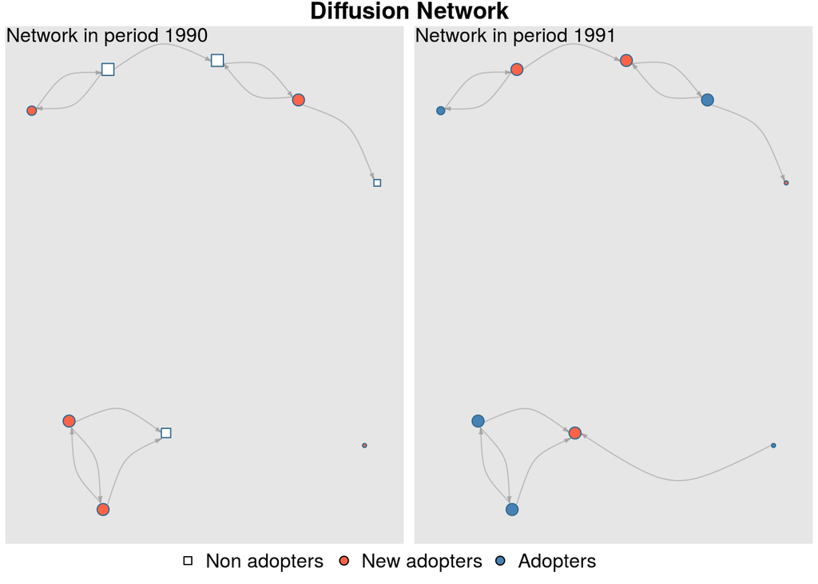

```r
plot_diffnet(diffnet_dynsurvey)
```

# Other formats

- The package also supports working with other network formats.
- Besides of `.net` (Pajek), and `ml` (UCINET), netdiffuseR can actually convert between classes: `igraph`, `network`, and `networkDynamic`.

  ```r
  data("medInnovationsDiffNet")
  dn_ig  <- diffnet_to_igraph(medInnovationsDiffNet)
  # dn_ig # For some issue with lazy eval, knitr won't print this

  dn_net <- diffnet_to_network(medInnovationsDiffNet)
  dn_net[[1]]
  ```

  ```
  #  Network attributes:
  #   vertices = 125
  #   directed = TRUE
  #   hyper = FALSE
  #   loops = FALSE
  #   multiple = FALSE
  #   bipartite = FALSE
  #   name = Medical Innovation
  #   behavior = Adoption of Tetracycline
  #   total edges= 294
  #     missing edges= 0
  #     non-missing edges= 294
  #
  #  Vertex attribute names:
  #     ado adopt attend belief catbak city club coll commun ctl date detail detail2 dichot drug expect free friends here home house info journ journ2 length meet most net1_1 net1_2 net1_3 net2_1 net2_2 net2_3 net3_1 net3_2 net3_3 nojourn nonpoor office origid paadico perc position presc proage proage…
  #
  # No edge attributes
  ```

  ```r
  dn_ndy <- diffnet_to_networkDynamic(medInnovationsDiffNet)
  ```

  ```
  # Argument base.net not specified, using first element of network.list instead
  # Created net.obs.period to describe network
  #  Network observation period info:
  #   Number of observation spells: 1
  #   Maximal time range observed: 1 until 18
  #   Temporal mode: discrete
  #   Time unit: step
  #   Suggested time increment: 1
  ```

  ```r
  dn_ndy
  ```

  ```
  # NetworkDynamic properties:
  #   distinct change times: 18
  #   maximal time range: 1 until  18
  #
  # Includes optional net.obs.period attribute:
  #  Network observation period info:
  #   Number of observation spells: 1
  #   Maximal time range observed: 1 until 18
  #   Temporal mode: discrete
  #   Time unit: step
  #   Suggested time increment: 1
  #
  #  Network attributes:
  #   vertices = 125
  #   directed = TRUE
  #   hyper = FALSE
  #   loops = FALSE
  #   multiple = FALSE
  #   bipartite = FALSE
  #   behavior = Adoption of Tetracycline
  #   name = Medical Innovation
  #   net.obs.period: (not shown)
  #   total edges= 294
  #     missing edges= 0
  #     non-missing edges= 294
  #
  #  Vertex attribute names:
  #     active ado adopt attend belief catbak city club coll commun ctl date detail detail2 dichot drug expect free friends here home house info journ journ2 length meet most net1_1 net1_2 net1_3 net2_1 net2_2 net2_3 net3_1 net3_2 net3_3 nojourn nonpoor office origid paadico perc position presc proage…
  #
  #  Edge attribute names:
  #     active
  ```

  First two examples it creates a list of objects, the later actually creates a single object

  ```r
  networkDynamic_to_diffnet(dn_ndy, toavar = "toa")
  ```

  ```
  # Dynamic network of class -diffnet-
  #  Name               : Medical Innovation
  #  Behavior           : Adoption of Tetracycline
  #  # of nodes         : 125 (1001, 1002, 1003, 1004, 1005, 1006, 1007, 1008, ...)
  #  # of time periods  : 18 (1 - 18)
  #  Type               : directed
  #  Final prevalence   : 1.00
  #  Static attributes  : -
  #  Dynamic attributes : ado, adopt, attend, belief, catbak, city, club, co... (59)
  ```

# Problems

University of Southern California  
Center for Applied Network Analysis (**CANA**)